# Prediction of benign or malignant cancer tumors

### Importing and Merging Data

```python
# Importing Pandas and NumPy
import pandas as pd
import numpy as np
import matplotlib.pyplot as plt
import seaborn as sns
```

```python
wpbc_data = pd.read_csv(r"C:\Users\chandrasen.wadikar\Desktop\sezzle assignment\wpbc.data")
```

```python
print(len(wpbc_data))
```

```
197
```

```python
wpbc_data.head()
```

|  | 119513 | N | 31 | 18.02 | 27.6 | 117.5 | 1013 | 0.09489 | 0.1036 | 0.1086 | ... | 139.7 | 1436 | 0.1195 | 0.1926 | 0.314 | 0.117 | 0.2677 | 0.08113 | 5 | 5.1 |
| --- | --- | --- | --- | --- | --- | --- | --- | --- | --- | --- | --- | --- | --- | --- | --- | --- | --- | --- | --- | --- | --- |
| 0 | 8423 | N | 61 | 17.99 | 10.38 | 122.80 | 1001.0 | 0.11840 | 0.2776 | 0.3001 | ... | 184.60 | 2019.0 | 0.1622 | 0.6656 | 0.7119 | 0.2654 | 0.4601 | 0.11890 | 3.0 | 2 |
| 1 | 842517 | N | 116 | 21.37 | 17.44 | 137.50 | 1373.0 | 0.08836 | 0.1189 | 0.1255 | ... | 159.10 | 1949.0 | 0.1188 | 0.3449 | 0.3414 | 0.2032 | 0.4334 | 0.09067 | 2.5 | 0 |
| 2 | 843483 | N | 123 | 11.42 | 20.38 | 77.58 | 386.1 | 0.14250 | 0.2839 | 0.2414 | ... | 98.87 | 567.7 | 0.2098 | 0.8663 | 0.6869 | 0.2575 | 0.6638 | 0.17300 | 2.0 | 0 |
| 3 | 843584 | R | 27 | 20.29 | 14.34 | 135.10 | 1297.0 | 0.10030 | 0.1328 | 0.1980 | ... | 152.20 | 1575.0 | 0.1374 | 0.2050 | 0.4000 | 0.1625 | 0.2364 | 0.07678 | 3.5 | 0 |
| 4 | 843786 | R | 77 | 12.75 | 15.29 | 84.60 | 502.7 | 0.11890 | 0.1569 | 0.1664 | ... | 107.30 | 733.2 | 0.1706 | 0.4196 | 0.5999 | 0.1709 | 0.3485 | 0.11790 | 2.5 | 0 |

5 rows × 35 columns

```python
wpbc_data.columns = ['ID Number','Outcome','Time','Realvalued Features1','Realvalued Features2','Realvalued Features3',
                      'Realvalued Features4','Realvalued Features5','Realvalued Features6','Realvalued Features7',
                      'Realvalued Features8','Realvalued Features9','Realvalued Features10','Realvalued Features11','Realvalued Features12','Realvalued Features13','Realvalued Features14','Realvalued Features15','Realvalued Features16','Realvalued Features17','Realvalued Features18','Realvalued Features19','Realvalued Features20','Realvalued Features21','Realvalued Features22','Radius','Texture','Perimeter',
                       'Area','Smoothness','Compactness','Concavity','Concave Points','Symmetry','Fractal Dimension']
```

```python
wpbc_data.info()
```

```
<class 'pandas.core.frame.DataFrame'>
RangeIndex: 197 entries, 0 to 196
Data columns (total 35 columns):
ID Number                197 non-null int64
Outcome                  197 non-null object
Time                     197 non-null int64
Realvalued Features1     197 non-null float64
Realvalued Features2     197 non-null float64
Realvalued Features3     197 non-null float64
Realvalued Features4     197 non-null float64
Realvalued Features5     197 non-null float64
Realvalued Features6     197 non-null float64
Realvalued Features7     197 non-null float64
Realvalued Features8     197 non-null float64
Realvalued Features9     197 non-null float64
Realvalued Features10    197 non-null float64
Realvalued Features11    197 non-null float64
Realvalued Features12    197 non-null float64
Realvalued Features13    197 non-null float64
Realvalued Features14    197 non-null float64
Realvalued Features15    197 non-null float64
Realvalued Features16    197 non-null float64
Realvalued Features17    197 non-null float64
Realvalued Features18    197 non-null float64
Realvalued Features19    197 non-null float64
Realvalued Features20    197 non-null float64
Realvalued Features21    197 non-null float64
Realvalued Features22    197 non-null float64
Radius                   197 non-null float64
Texture                  197 non-null float64
Perimeter                197 non-null float64
Area                     197 non-null float64
Smoothness               197 non-null float64
Compactness              197 non-null float64
Concavity                197 non-null float64
Concave Points           197 non-null float64
Symmetry                 197 non-null float64
Fractal Dimension        197 non-null object
dtypes: float64(31), int64(2), object(2)
memory usage: 53.9+ KB
```

### Let's understand strucutre of DataFrame and Null values

```python
### Checking the percentage of missing values
round(100*(wpbc_data.isnull().sum()/len(wpbc_data.index)), 2)
```

```
ID Number                0.0
Outcome                  0.0
Time                     0.0
Realvalued Features1     0.0
Realvalued Features2     0.0
Realvalued Features3     0.0
Realvalued Features4     0.0
Realvalued Features5     0.0
Realvalued Features6     0.0
Realvalued Features7     0.0
Realvalued Features8     0.0
Realvalued Features9     0.0
Realvalued Features10    0.0
Realvalued Features11    0.0
Realvalued Features12    0.0
Realvalued Features13    0.0
Realvalued Features14    0.0
Realvalued Features15    0.0
Realvalued Features16    0.0
Realvalued Features17    0.0
Realvalued Features18    0.0
Realvalued Features19    0.0
Realvalued Features20    0.0
Realvalued Features21    0.0
Realvalued Features22    0.0
Radius                   0.0
Texture                  0.0
Perimeter                0.0
Area                     0.0
Smoothness               0.0
Compactness              0.0
Concavity                0.0
Concave Points           0.0
Symmetry                 0.0
Fractal Dimension        0.0
dtype: float64
```

```python
wpbc_data.shape
```

```
(197, 35)
```

```python
wpbc_data.head()
```

|  | ID Number | Outcome | Time | Realvalued Features1 | Realvalued Features2 | Realvalued Features3 | Realvalued Features4 | Realvalued Features5 | Realvalued Features6 | Realvalued Features7 | ... | Radius | Texture | Perimeter | Area | Smoothness | Compactness | Concavity | Concave Points | Symmetry | Fractal Dimension |
| --- | --- | --- | --- | --- | --- | --- | --- | --- | --- | --- | --- | --- | --- | --- | --- | --- | --- | --- | --- | --- | --- |
| 0 | 8423 | N | 61 | 17.99 | 10.38 | 122.80 | 1001.0 | 0.11840 | 0.2776 | 0.3001 | ... | 184.60 | 2019.0 | 0.1622 | 0.6656 | 0.7119 | 0.2654 | 0.4601 | 0.11890 | 3.0 | 2 |
| 1 | 842517 | N | 116 | 21.37 | 17.44 | 137.50 | 1373.0 | 0.08836 | 0.1189 | 0.1255 | ... | 159.10 | 1949.0 | 0.1188 | 0.3449 | 0.3414 | 0.2032 | 0.4334 | 0.09067 | 2.5 | 0 |
| 2 | 843483 | N | 123 | 11.42 | 20.38 | 77.58 | 386.1 | 0.14250 | 0.2839 | 0.2414 | ... | 98.87 | 567.7 | 0.2098 | 0.8663 | 0.6869 | 0.2575 | 0.6638 | 0.17300 | 2.0 | 0 |
| 3 | 843584 | R | 27 | 20.29 | 14.34 | 135.10 | 1297.0 | 0.10030 | 0.1328 | 0.1980 | ... | 152.20 | 1575.0 | 0.1374 | 0.2050 | 0.4000 | 0.1625 | 0.2364 | 0.07678 | 3.5 | 0 |
| 4 | 843786 | R | 77 | 12.75 | 15.29 | 84.60 | 502.7 | 0.11890 | 0.1569 | 0.1664 | ... | 107.30 | 733.2 | 0.1706 | 0.4196 | 0.5999 | 0.1709 | 0.3485 | 0.11790 | 2.5 | 0 |

5 rows × 35 columns

```python
wpbc_data.isnull().sum()
```

```
ID Number                0
Outcome                  0
Time                     0
Realvalued Features1     0
Realvalued Features2     0
Realvalued Features3     0
Realvalued Features4     0
Realvalued Features5     0
Realvalued Features6     0
Realvalued Features7     0
Realvalued Features8     0
Realvalued Features9     0
Realvalued Features10    0
Realvalued Features11    0
Realvalued Features12    0
Realvalued Features13    0
Realvalued Features14    0
Realvalued Features15    0
Realvalued Features16    0
Realvalued Features17    0
Realvalued Features18    0
Realvalued Features19    0
Realvalued Features20    0
Realvalued Features21    0
Realvalued Features22    0
Radius                   0
Texture                  0
Perimeter                0
Area                     0
Smoothness               0
Compactness              0
Concavity                0
Concave Points           0
Symmetry                 0
Fractal Dimension        0
dtype: int64
```

```python
wpbc_data.info()
```

```
<class 'pandas.core.frame.DataFrame'>
RangeIndex: 197 entries, 0 to 196
Data columns (total 35 columns):
ID Number                197 non-null int64
Outcome                  197 non-null object
Time                     197 non-null int64
Realvalued Features1     197 non-null float64
Realvalued Features2     197 non-null float64
Realvalued Features3     197 non-null float64
Realvalued Features4     197 non-null float64
Realvalued Features5     197 non-null float64
Realvalued Features6     197 non-null float64
Realvalued Features7     197 non-null float64
Realvalued Features8     197 non-null float64
Realvalued Features9     197 non-null float64
Realvalued Features10    197 non-null float64
Realvalued Features11    197 non-null float64
Realvalued Features12    197 non-null float64
Realvalued Features13    197 non-null float64
Realvalued Features14    197 non-null float64
Realvalued Features15    197 non-null float64
Realvalued Features16    197 non-null float64
Realvalued Features17    197 non-null float64
Realvalued Features18    197 non-null float64
Realvalued Features19    197 non-null float64
Realvalued Features20    197 non-null float64
Realvalued Features21    197 non-null float64
Realvalued Features22    197 non-null float64
Radius                   197 non-null float64
Texture                  197 non-null float64
Perimeter                197 non-null float64
Area                     197 non-null float64
Smoothness               197 non-null float64
Compactness              197 non-null float64
Concavity                197 non-null float64
Concave Points           197 non-null float64
Symmetry                 197 non-null float64
Fractal Dimension        197 non-null object
dtypes: float64(31), int64(2), object(2)
memory usage: 53.9+ KB
```

```python
# Converting Yes to 1 and No to 0
wpbc_data['Outcome'] = wpbc_data['Outcome'].map({'N': 1, 'R': 0})
```

```python
wpbc_data.head()
```

|  | ID Number | Outcome | Time | Realvalued Features1 | Realvalued Features2 | Realvalued Features3 | Realvalued Features4 | Realvalued Features5 | Realvalued Features6 | Realvalued Features7 | ... | Radius | Texture | Perimeter | Area | Smoothness | Compactness | Concavity | Concave Points | Symmetry | Fractal Dimension |
| --- | --- | --- | --- | --- | --- | --- | --- | --- | --- | --- | --- | --- | --- | --- | --- | --- | --- | --- | --- | --- | --- |
| 0 | 8423 | 1 | 61 | 17.99 | 10.38 | 122.80 | 1001.0 | 0.11840 | 0.2776 | 0.3001 | ... | 184.60 | 2019.0 | 0.1622 | 0.6656 | 0.7119 | 0.2654 | 0.4601 | 0.11890 | 3.0 | 2 |
| 1 | 842517 | 1 | 116 | 21.37 | 17.44 | 137.50 | 1373.0 | 0.08836 | 0.1189 | 0.1255 | ... | 159.10 | 1949.0 | 0.1188 | 0.3449 | 0.3414 | 0.2032 | 0.4334 | 0.09067 | 2.5 | 0 |
| 2 | 843483 | 1 | 123 | 11.42 | 20.38 | 77.58 | 386.1 | 0.14250 | 0.2839 | 0.2414 | ... | 98.87 | 567.7 | 0.2098 | 0.8663 | 0.6869 | 0.2575 | 0.6638 | 0.17300 | 2.0 | 0 |
| 3 | 843584 | 0 | 27 | 20.29 | 14.34 | 135.10 | 1297.0 | 0.10030 | 0.1328 | 0.1980 | ... | 152.20 | 1575.0 | 0.1374 | 0.2050 | 0.4000 | 0.1625 | 0.2364 | 0.07678 | 3.5 | 0 |
| 4 | 843786 | 0 | 77 | 12.75 | 15.29 | 84.60 | 502.7 | 0.11890 | 0.1569 | 0.1664 | ... | 107.30 | 733.2 | 0.1706 | 0.4196 | 0.5999 | 0.1709 | 0.3485 | 0.11790 | 2.5 | 0 |

5 rows × 35 columns

### Check the different attribute and rate to probability of diesease

```python
Concavity = (sum(wpbc_data['Concavity'])/len(wpbc_data['Concavity'].index))*100
Concavity
```

```
32.36868020304567
```

```python
Radius = (sum(wpbc_data['Radius'])/len(wpbc_data['Radius'].index))*100
Radius
```

```
14035.106598984768
```

```python
ConcavePoints = (sum(wpbc_data['Concave Points'])/len(wpbc_data['Concave Points'].index))*100
ConcavePoints
```

```
9.087736040609135
```

```python
Compactness = (sum(wpbc_data['Compactness'])/len(wpbc_data['Compactness'].index))*100
Compactness
```

```
17.909111675126912
```

```python
Area = (sum(wpbc_data['Area'])/len(wpbc_data['Area'].index))*100
Area
```

```
36.59774619289336
```

```python
smoothness = (sum(wpbc_data['Smoothness'])/len(wpbc_data['Smoothness'].index))*100
smoothness
```

```
43.730807106598974
```

```python
perimeter = (sum(wpbc_data['Perimeter'])/len(wpbc_data['Perimeter'].index))*100
perimeter
```

```
14.404472081218266
```

### Model Building

#### Splitting Data into Training and Test Sets

```python
from sklearn.model_selection import train_test_split

# Putting feature variable to X
X = wpbc_data.drop(['Outcome','ID Number'],axis=1)

# Putting response variable to y
y = wpbc_data['Outcome']

y.head()
```

[output not shown]

```python
# Splitting the data into train and test
X_train, X_test, y_train, y_test = train_test_split(X, y, test_size=0.30, random_state=101)
```

```python
# Converting String (?) to float
wpbc_data = wpbc_data.replace('?', regex=True).astype(float)
```

### Correlation Matrix

```python
# Importing matplotlib and seaborn
import matplotlib.pyplot as plt
import seaborn as sns
%matplotlib inline
```

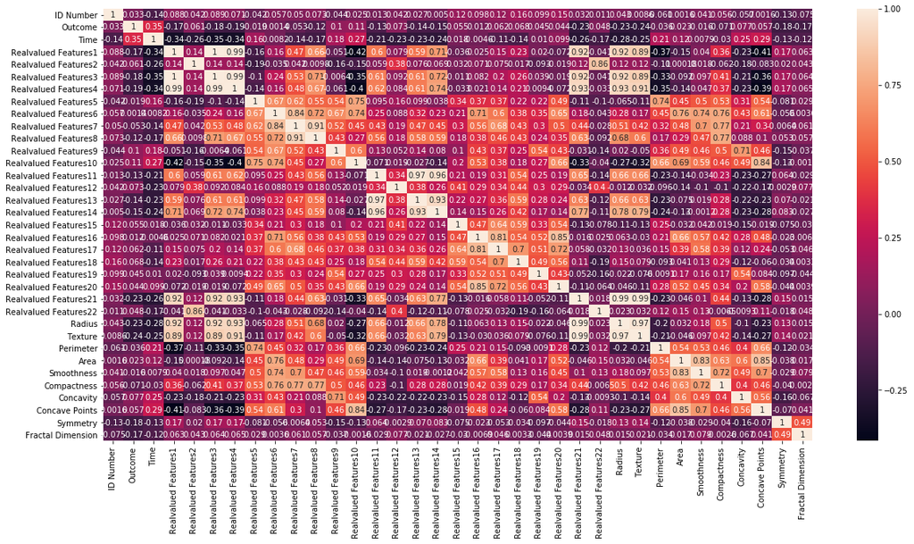

```python
# Let's see the correlation matrix
plt.figure(figsize = (20,10))        # Size of the figure
sns.heatmap(wpbc_data.corr(),annot = True)
```

```python
# Special charaters, is handled with the space.
##removeSpecialChars = wpbc_data.replace ({ord(c): 0.00 for c in '?'})
```

### Dropping highly corelated observation

```python
X_test2 = X_test.drop(['Realvalued Features1','Realvalued Features3','Realvalued Features4','Realvalued Features7','Realvalued Features8','Realvalued Features13','Realvalued Features14','Realvalued Features21','Realvalued Features22','Radius','Texture'],1)
X_train2 = X_train.drop(['Realvalued Features1','Realvalued Features3','Realvalued Features4','Realvalued Features7','Realvalued Features8','Realvalued Features13','Realvalued Features14','Realvalued Features21','Realvalued Features22','Radius','Texture'],1)
```

#### Checking the Correlation Matrix

##### After dropping highly correlated variables now let's check the correlation matrix again.

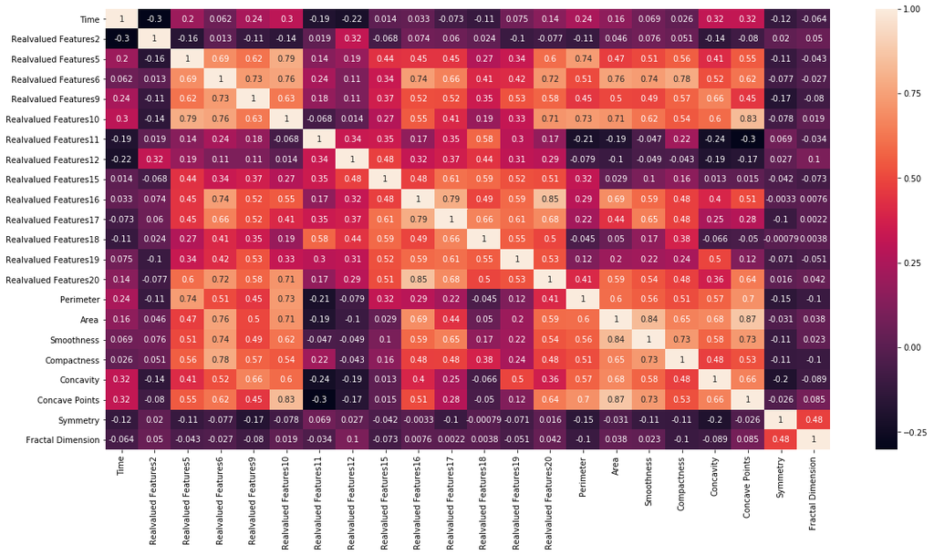

```python
plt.figure(figsize = (20,10))
sns.heatmap(X_train2.corr(),annot = True)
```

### Random Forest

```python
# Importing random forest classifier from sklearn library
from sklearn.ensemble import RandomForestClassifier

# Running the random forest with default parameters.
rfc = RandomForestClassifier()
```

```python
# fit
rfc.fit(X_train2,y_train)
```

```
RandomForestClassifier(bootstrap=True, class_weight=None, criterion='gini',
            max_depth=None, max_features='auto', max_leaf_nodes=None,
            min_impurity_decrease=0.0, min_impurity_split=None,
            min_samples_leaf=1, min_samples_split=2,
            min_weight_fraction_leaf=0.0, n_estimators=10, n_jobs=1,
            oob_score=False, random_state=None, verbose=0,
            warm_start=False)
```

```python
# Making predictions
predictions = rfc.predict(X_test2)
```

```python
# Importing classification report and confusion matrix from sklearn metrics
from sklearn.metrics import classification_report,confusion_matrix, accuracy_score
```

```python
# Let's check the report of our default model
print(classification_report(y_test,predictions))
```

```
             precision    recall  f1-score   support

        0.0       0.55      0.29      0.37        21
        1.0       0.69      0.87      0.77        39

avg / total       0.64      0.67      0.63        60
```

```python
# Printing confusion matrix
print(confusion_matrix(y_test,predictions))
```

```
[[ 6 15]
 [ 5 34]]
```

```python
print(accuracy_score(y_test,predictions))
```

```
0.6666666666666666
```

### Hyperparameter Tuning

#### Tuning max_depth

```python
## Let's try to find the optimum values for max_depth and understand how the value of max_depth impacts the overall accuracy of the ensemble.

# GridSearchCV to find optimal n_estimators
from sklearn.model_selection import KFold
from sklearn.model_selection import GridSearchCV


# specify number of folds for k-fold CV
n_folds = 5

# parameters to build the model on
parameters = {'max_depth': range(2, 20, 5)}

# instantiate the model
rf = RandomForestClassifier()


# fit tree on training data
rf = GridSearchCV(rf, parameters,
                    cv=n_folds,
                   scoring="accuracy")
rf.fit(X_train2, y_train)
```

```
GridSearchCV(cv=5, error_score='raise',
       estimator=RandomForestClassifier(bootstrap=True, class_weight=None, criterion='gini',
            max_depth=None, max_features='auto', max_leaf_nodes=None,
            min_impurity_decrease=0.0, min_impurity_split=None,
            min_samples_leaf=1, min_samples_split=2,
            min_weight_fraction_leaf=0.0, n_estimators=10, n_jobs=1,
            oob_score=False, random_state=None, verbose=0,
            warm_start=False),
       fit_params=None, iid=True, n_jobs=1,
       param_grid={'max_depth': range(2, 20, 5)}, pre_dispatch='2*n_jobs',
       refit=True, return_train_score='warn', scoring='accuracy',
       verbose=0)
```

```python
# scores of GridSearch CV
scores = rf.cv_results_
pd.DataFrame(scores).head()
```

|  | mean_fit_time | std_fit_time | mean_score_time | std_score_time | param_max_depth | params | split0_test_score | split1_test_score | split2_test_score | split3_test_score | ... | mean_test_score | std_test_score | rank_test_score | split0_train_score | split1_train_score | split2_train_score | split3_train_score | split4_train_score | mean_train_score | std_train_score |
| --- | --- | --- | --- | --- | --- | --- | --- | --- | --- | --- | --- | --- | --- | --- | --- | --- | --- | --- | --- | --- | --- |
| 0 | 0.015626 | 0.000002 | 0.000000 | 0.000000 | 2 | {'max_depth': 2} | 0.793103 | 0.777778 | 0.814815 | 0.814815 | ... | 0.795620 | 0.016494 | 1 | 0.851852 | 0.863636 | 0.818182 | 0.809091 | 0.854545 | 0.839461 | 0.021636 |
| 1 | 0.021876 | 0.007655 | 0.000000 | 0.000000 | 7 | {'max_depth': 7} | 0.724138 | 0.777778 | 0.777778 | 0.777778 | ... | 0.781022 | 0.040987 | 2 | 0.981481 | 0.990909 | 0.981818 | 0.981818 | 0.990909 | 0.985387 | 0.004510 |
| 2 | 0.012500 | 0.006250 | 0.003125 | 0.006251 | 12 | {'max_depth': 12} | 0.793103 | 0.666667 | 0.703704 | 0.851852 | ... | 0.766423 | 0.069188 | 3 | 1.000000 | 1.000000 | 0.981818 | 0.990909 | 0.990909 | 0.992727 | 0.006803 |
| 3 | 0.015625 | 0.000011 | 0.000000 | 0.000000 | 17 | {'max_depth': 17} | 0.758621 | 0.703704 | 0.851852 | 0.740741 | ... | 0.759124 | 0.049327 | 4 | 1.000000 | 1.000000 | 0.981818 | 0.990909 | 0.990909 | 0.992727 | 0.006803 |

4 rows × 21 columns

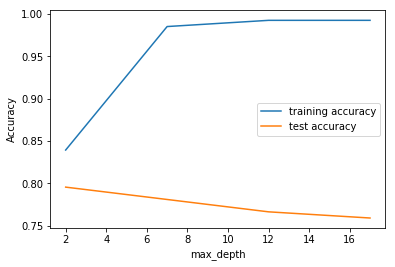

```python
# plotting accuracies with max_depth
plt.figure()
plt.plot(scores["param_max_depth"],
         scores["mean_train_score"],
         label="training accuracy")
plt.plot(scores["param_max_depth"],
         scores["mean_test_score"],
         label="test accuracy")
plt.xlabel("max_depth")
plt.ylabel("Accuracy")
plt.legend()
plt.show()
```

### Tuning n_estimators

```python
# GridSearchCV to find optimal n_estimators
from sklearn.model_selection import KFold
from sklearn.model_selection import GridSearchCV


# specify number of folds for k-fold CV
n_folds = 5

# parameters to build the model on
parameters = {'n_estimators': range(100, 1500, 400)}

# instantiate the model (note we are specifying a max_depth)
rf = RandomForestClassifier(max_depth=4)


# fit tree on training data
rf = GridSearchCV(rf, parameters,
                    cv=n_folds,
                   scoring="accuracy")
rf.fit(X_train2, y_train)
```

```
GridSearchCV(cv=5, error_score='raise',
       estimator=RandomForestClassifier(bootstrap=True, class_weight=None, criterion='gini',
            max_depth=4, max_features='auto', max_leaf_nodes=None,
            min_impurity_decrease=0.0, min_impurity_split=None,
            min_samples_leaf=1, min_samples_split=2,
            min_weight_fraction_leaf=0.0, n_estimators=10, n_jobs=1,
            oob_score=False, random_state=None, verbose=0,
            warm_start=False),
       fit_params=None, iid=True, n_jobs=1,
       param_grid={'n_estimators': range(100, 1500, 400)},
       pre_dispatch='2*n_jobs', refit=True, return_train_score='warn',
       scoring='accuracy', verbose=0)
```

```python
# scores of GridSearch CV
scores = rf.cv_results_
pd.DataFrame(scores).head()
```

|  | mean_fit_time | std_fit_time | mean_score_time | std_score_time | param_n_estimators | params | split0_test_score | split1_test_score | split2_test_score | split3_test_score | ... | mean_test_score | std_test_score | rank_test_score | split0_train_score | split1_train_score | split2_train_score | split3_train_score | split4_train_score | mean_train_score | std_train_score |
| --- | --- | --- | --- | --- | --- | --- | --- | --- | --- | --- | --- | --- | --- | --- | --- | --- | --- | --- | --- | --- | --- |
| 0 | 0.127687 | 0.012764 | 0.009525 | 0.005907 | 100 | {'n_estimators': 100} | 0.793103 | 0.777778 | 0.814815 | 0.814815 | ... | 0.802920 | 0.015121 | 4 | 0.935185 | 0.936364 | 0.918182 | 0.945455 | 0.936364 | 0.934310 | 0.008872 |
| 1 | 0.581052 | 0.006116 | 0.030253 | 0.003139 | 500 | {'n_estimators': 500} | 0.793103 | 0.814815 | 0.814815 | 0.814815 | ... | 0.810219 | 0.008869 | 1 | 0.925926 | 0.936364 | 0.936364 | 0.945455 | 0.945455 | 0.937912 | 0.007242 |
| 2 | 1.050326 | 0.030947 | 0.053327 | 0.007447 | 900 | {'n_estimators': 900} | 0.793103 | 0.814815 | 0.814815 | 0.814815 | ... | 0.810219 | 0.008869 | 1 | 0.916667 | 0.954545 | 0.945455 | 0.963636 | 0.945455 | 0.945152 | 0.015758 |
| 3 | 1.491488 | 0.027526 | 0.078022 | 0.003103 | 1300 | {'n_estimators': 1300} | 0.793103 | 0.814815 | 0.814815 | 0.814815 | ... | 0.810219 | 0.008869 | 1 | 0.916667 | 0.936364 | 0.954545 | 0.954545 | 0.954545 | 0.943333 | 0.015079 |

4 rows × 21 columns

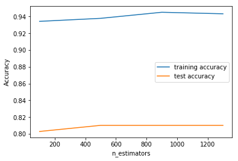

```python
# plotting accuracies with n_estimators
plt.figure()
plt.plot(scores["param_n_estimators"],
         scores["mean_train_score"],
         label="training accuracy")
plt.plot(scores["param_n_estimators"],
         scores["mean_test_score"],
         label="test accuracy")
plt.xlabel("n_estimators")
plt.ylabel("Accuracy")
plt.legend()
plt.show()
```

#### Tuning max_features

how the model performance varies with max_features, which is the maximum numbre of features considered for splitting at a node.

```python
# GridSearchCV to find optimal max_features
from sklearn.model_selection import KFold
from sklearn.model_selection import GridSearchCV


# specify number of folds for k-fold CV
n_folds = 5

# parameters to build the model on
parameters = {'max_features': [4, 8, 14, 20, 24]}

# instantiate the model
rf = RandomForestClassifier(max_depth=4)


# fit tree on training data
rf = GridSearchCV(rf, parameters,
                    cv=n_folds,
                   scoring="accuracy")
rf.fit(X_train, y_train)
```

```
GridSearchCV(cv=5, error_score='raise',
       estimator=RandomForestClassifier(bootstrap=True, class_weight=None, criterion='gini',
            max_depth=4, max_features='auto', max_leaf_nodes=None,
            min_impurity_decrease=0.0, min_impurity_split=None,
            min_samples_leaf=1, min_samples_split=2,
            min_weight_fraction_leaf=0.0, n_estimators=10, n_jobs=1,
            oob_score=False, random_state=None, verbose=0,
            warm_start=False),
       fit_params=None, iid=True, n_jobs=1,
       param_grid={'max_features': [4, 8, 14, 20, 24]},
       pre_dispatch='2*n_jobs', refit=True, return_train_score='warn',
       scoring='accuracy', verbose=0)
```

```python
# scores of GridSearch CV
scores = rf.cv_results_
pd.DataFrame(scores).head()
```

|  | mean_fit_time | std_fit_time | mean_score_time | std_score_time | param_max_features | params | split0_test_score | split1_test_score | split2_test_score | split3_test_score | ... | mean_test_score | std_test_score | rank_test_score | split0_train_score | split1_train_score | split2_train_score | split3_train_score | split4_train_score | mean_train_score | std_train_score |
| --- | --- | --- | --- | --- | --- | --- | --- | --- | --- | --- | --- | --- | --- | --- | --- | --- | --- | --- | --- | --- | --- |
| 0 | 0.017602 | 0.003199 | 0.003203 | 0.003923 | 4 | {'max_features': 4} | 0.793103 | 0.777778 | 0.777778 | 0.814815 | ... | 0.795620 | 0.016494 | 2 | 0.907407 | 0.963636 | 0.918182 | 0.936364 | 0.900000 | 0.925118 | 0.022816 |
| 1 | 0.015994 | 0.005065 | 0.003200 | 0.003920 | 8 | {'max_features': 8} | 0.793103 | 0.703704 | 0.777778 | 0.777778 | ... | 0.773723 | 0.037215 | 4 | 0.907407 | 0.945455 | 0.936364 | 0.945455 | 0.909091 | 0.928754 | 0.017077 |
| 2 | 0.015998 | 0.000007 | 0.000000 | 0.000000 | 14 | {'max_features': 14} | 0.793103 | 0.740741 | 0.814815 | 0.851852 | ... | 0.810219 | 0.041240 | 1 | 0.972222 | 0.963636 | 0.963636 | 0.963636 | 0.990909 | 0.970808 | 0.010586 |
| 3 | 0.019202 | 0.003920 | 0.000000 | 0.000000 | 20 | {'max_features': 20} | 0.793103 | 0.814815 | 0.814815 | 0.740741 | ... | 0.781022 | 0.033475 | 3 | 0.935185 | 0.945455 | 0.945455 | 0.972727 | 0.954545 | 0.950673 | 0.012615 |
| 4 | 0.019201 | 0.003920 | 0.000000 | 0.000000 | 24 | {'max_features': 24} | 0.758621 | 0.740741 | 0.814815 | 0.740741 | ... | 0.751825 | 0.036007 | 5 | 0.953704 | 0.981818 | 0.963636 | 0.972727 | 0.963636 | 0.967104 | 0.009505 |

5 rows × 21 columns

```python
# plotting accuracies with max_features
plt.figure()
plt.plot(scores["param_max_features"],
         scores["mean_train_score"],
         label="training accuracy")
plt.plot(scores["param_max_features"],
         scores["mean_test_score"],
         label="test accuracy")
plt.xlabel("max_features")
plt.ylabel("Accuracy")
plt.legend()
plt.show()
```

[output not shown]

### Tuning min_samples_leaf

```python
# GridSearchCV to find optimal min_samples_leaf
from sklearn.model_selection import KFold
from sklearn.model_selection import GridSearchCV


# specify number of folds for k-fold CV
n_folds = 5

# parameters to build the model on
parameters = {'min_samples_leaf': range(100, 400, 50)}

# instantiate the model
rf = RandomForestClassifier()


# fit tree on training data
rf = GridSearchCV(rf, parameters,
                    cv=n_folds,
                   scoring="accuracy")
rf.fit(X_train, y_train)
```

```
GridSearchCV(cv=5, error_score='raise',
       estimator=RandomForestClassifier(bootstrap=True, class_weight=None, criterion='gini',
            max_depth=None, max_features='auto', max_leaf_nodes=None,
            min_impurity_decrease=0.0, min_impurity_split=None,
            min_samples_leaf=1, min_samples_split=2,
            min_weight_fraction_leaf=0.0, n_estimators=10, n_jobs=1,
            oob_score=False, random_state=None, verbose=0,
            warm_start=False),
       fit_params=None, iid=True, n_jobs=1,
       param_grid={'min_samples_leaf': range(100, 400, 50)},
       pre_dispatch='2*n_jobs', refit=True, return_train_score='warn',
       scoring='accuracy', verbose=0)
```

```python
# scores of GridSearch CV
scores = rf.cv_results_
pd.DataFrame(scores).head()
```

|  | mean_fit_time | std_fit_time | mean_score_time | std_score_time | param_min_samples_leaf | params | split0_test_score | split1_test_score | split2_test_score | split3_test_score | ... | mean_test_score | std_test_score | rank_test_score | split0_train_score | split1_train_score | split2_train_score | split3_train_score | split4_train_score | mean_train_score | std_train_score |
| --- | --- | --- | --- | --- | --- | --- | --- | --- | --- | --- | --- | --- | --- | --- | --- | --- | --- | --- | --- | --- | --- |
| 0 | 0.019201 | 0.003919 | 0.0016 | 0.003201 | 100 | {'min_samples_leaf': 100} | 0.793103 | 0.814815 | 0.814815 | 0.814815 | ... | 0.810219 | 0.008869 | 1 | 0.814815 | 0.809091 | 0.809091 | 0.809091 | 0.809091 | 0.810236 | 0.00229 |
| 1 | 0.014397 | 0.003208 | 0.0000 | 0.000000 | 150 | {'min_samples_leaf': 150} | 0.793103 | 0.814815 | 0.814815 | 0.814815 | ... | 0.810219 | 0.008869 | 1 | 0.814815 | 0.809091 | 0.809091 | 0.809091 | 0.809091 | 0.810236 | 0.00229 |
| 2 | 0.012804 | 0.003920 | 0.0016 | 0.003200 | 200 | {'min_samples_leaf': 200} | 0.793103 | 0.814815 | 0.814815 | 0.814815 | ... | 0.810219 | 0.008869 | 1 | 0.814815 | 0.809091 | 0.809091 | 0.809091 | 0.809091 | 0.810236 | 0.00229 |
| 3 | 0.016008 | 0.005054 | 0.0016 | 0.003200 | 250 | {'min_samples_leaf': 250} | 0.793103 | 0.814815 | 0.814815 | 0.814815 | ... | 0.810219 | 0.008869 | 1 | 0.814815 | 0.809091 | 0.809091 | 0.809091 | 0.809091 | 0.810236 | 0.00229 |
| 4 | 0.012801 | 0.003913 | 0.0000 | 0.000000 | 300 | {'min_samples_leaf': 300} | 0.793103 | 0.814815 | 0.814815 | 0.814815 | ... | 0.810219 | 0.008869 | 1 | 0.814815 | 0.809091 | 0.809091 | 0.809091 | 0.809091 | 0.810236 | 0.00229 |

5 rows × 21 columns

```python
# plotting accuracies with min_samples_leaf
plt.figure()
plt.plot(scores["param_min_samples_leaf"],
         scores["mean_train_score"],
         label="training accuracy")
plt.plot(scores["param_min_samples_leaf"],
         scores["mean_test_score"],
         label="test accuracy")
plt.xlabel("min_samples_leaf")
plt.ylabel("Accuracy")
plt.legend()
plt.show()
```

[output not shown]

### Tuning min_samples_split

Let's now look at the performance of the ensemble as we vary min_samples_split.

```python
# GridSearchCV to find optimal min_samples_split
from sklearn.model_selection import KFold
from sklearn.model_selection import GridSearchCV


# specify number of folds for k-fold CV
n_folds = 5

# parameters to build the model on
parameters = {'min_samples_split': range(200, 500, 50)}

# instantiate the model
rf = RandomForestClassifier()


# fit tree on training data
rf = GridSearchCV(rf, parameters,
                    cv=n_folds,
                   scoring="accuracy")
rf.fit(X_train, y_train)
```

```
GridSearchCV(cv=5, error_score='raise',
       estimator=RandomForestClassifier(bootstrap=True, class_weight=None, criterion='gini',
            max_depth=None, max_features='auto', max_leaf_nodes=None,
            min_impurity_decrease=0.0, min_impurity_split=None,
            min_samples_leaf=1, min_samples_split=2,
            min_weight_fraction_leaf=0.0, n_estimators=10, n_jobs=1,
            oob_score=False, random_state=None, verbose=0,
            warm_start=False),
       fit_params=None, iid=True, n_jobs=1,
       param_grid={'min_samples_split': range(200, 500, 50)},
       pre_dispatch='2*n_jobs', refit=True, return_train_score='warn',
       scoring='accuracy', verbose=0)
```

```python
# scores of GridSearch CV
scores = rf.cv_results_
pd.DataFrame(scores).head()
```

|  | mean_fit_time | std_fit_time | mean_score_time | std_score_time | param_min_samples_split | params | split0_test_score | split1_test_score | split2_test_score | split3_test_score | ... | mean_test_score | std_test_score | rank_test_score | split0_train_score | split1_train_score | split2_train_score | split3_train_score | split4_train_score | mean_train_score | std_train_score |
| --- | --- | --- | --- | --- | --- | --- | --- | --- | --- | --- | --- | --- | --- | --- | --- | --- | --- | --- | --- | --- | --- |
| 0 | 0.020803 | 0.003920 | 0.0000 | 0.000000 | 200 | {'min_samples_split': 200} | 0.793103 | 0.814815 | 0.814815 | 0.814815 | ... | 0.810219 | 0.008869 | 1 | 0.814815 | 0.809091 | 0.809091 | 0.809091 | 0.809091 | 0.810236 | 0.00229 |
| 1 | 0.014402 | 0.003200 | 0.0016 | 0.003201 | 250 | {'min_samples_split': 250} | 0.793103 | 0.814815 | 0.814815 | 0.814815 | ... | 0.810219 | 0.008869 | 1 | 0.814815 | 0.809091 | 0.809091 | 0.809091 | 0.809091 | 0.810236 | 0.00229 |
| 2 | 0.024002 | 0.007156 | 0.0016 | 0.003200 | 300 | {'min_samples_split': 300} | 0.793103 | 0.814815 | 0.814815 | 0.814815 | ... | 0.810219 | 0.008869 | 1 | 0.814815 | 0.809091 | 0.809091 | 0.809091 | 0.809091 | 0.810236 | 0.00229 |
| 3 | 0.017601 | 0.003200 | 0.0032 | 0.003919 | 350 | {'min_samples_split': 350} | 0.793103 | 0.814815 | 0.814815 | 0.814815 | ... | 0.810219 | 0.008869 | 1 | 0.814815 | 0.809091 | 0.809091 | 0.809091 | 0.809091 | 0.810236 | 0.00229 |
| 4 | 0.017403 | 0.007545 | 0.0000 | 0.000000 | 400 | {'min_samples_split': 400} | 0.793103 | 0.814815 | 0.814815 | 0.814815 | ... | 0.810219 | 0.008869 | 1 | 0.814815 | 0.809091 | 0.809091 | 0.809091 | 0.809091 | 0.810236 | 0.00229 |

5 rows × 21 columns

```python
# plotting accuracies with min_samples_split
plt.figure()
plt.plot(scores["param_min_samples_split"],
         scores["mean_train_score"],
         label="training accuracy")
plt.plot(scores["param_min_samples_split"],
         scores["mean_test_score"],
         label="test accuracy")
plt.xlabel("min_samples_split")
plt.ylabel("Accuracy")
plt.legend()
plt.show()
```

[output not shown]

### Grid Search to Find Optimal Hyperparameters

We can now find the optimal hyperparameters using GridSearchCV

```python
# Create the parameter grid based on the results of random search
param_grid = {
    'max_depth': [4,8,10],
    'min_samples_leaf': range(100, 400, 200),
    'min_samples_split': range(200, 500, 200),
    'n_estimators': [100,200, 300],
    'max_features': [5, 10]
}
# Create a based model
rf = RandomForestClassifier()
# Instantiate the grid search model
grid_search = GridSearchCV(estimator = rf, param_grid = param_grid,
                          cv = 3, n_jobs = -1,verbose = 1)
```

```python
# Fit the grid search to the data
grid_search.fit(X_train, y_train)
```

```
Fitting 3 folds for each of 72 candidates, totalling 216 fits
```

```
[Parallel(n_jobs=-1)]: Done  42 tasks      | elapsed:   28.4s
[Parallel(n_jobs=-1)]: Done 192 tasks      | elapsed:   46.7s
[Parallel(n_jobs=-1)]: Done 216 out of 216 | elapsed:   50.6s finished
```

```
GridSearchCV(cv=3, error_score='raise',
       estimator=RandomForestClassifier(bootstrap=True, class_weight=None, criterion='gini',
            max_depth=None, max_features='auto', max_leaf_nodes=None,
            min_impurity_decrease=0.0, min_impurity_split=None,
            min_samples_leaf=1, min_samples_split=2,
            min_weight_fraction_leaf=0.0, n_estimators=10, n_jobs=1,
            oob_score=False, random_state=None, verbose=0,
            warm_start=False),
       fit_params=None, iid=True, n_jobs=-1,
       param_grid={'max_depth': [4, 8, 10], 'min_samples_leaf': range(100, 400, 200), 'min_samples_split': range(200, 500, 200), 'n_estimators': [100, 200, 300], 'max_features': [5, 10]},
       pre_dispatch='2*n_jobs', refit=True, return_train_score='warn',
       scoring=None, verbose=1)
```

```python
# model with the best hyperparameters
from sklearn.ensemble import RandomForestClassifier
rfc = RandomForestClassifier(bootstrap=True,
                             max_depth=10,
                             min_samples_leaf=100,
                             min_samples_split=200,
                             max_features=10,
                             n_estimators=100)
```

```python
# fit
rfc.fit(X_train,y_train)
```

```
RandomForestClassifier(bootstrap=True, class_weight=None, criterion='gini',
            max_depth=10, max_features=10, max_leaf_nodes=None,
            min_impurity_decrease=0.0, min_impurity_split=None,
            min_samples_leaf=100, min_samples_split=200,
            min_weight_fraction_leaf=0.0, n_estimators=100, n_jobs=1,
            oob_score=False, random_state=None, verbose=0,
            warm_start=False)
```

```python
# predict
predictions = rfc.predict(X_test)
```

```python
# evaluation metrics
from sklearn.metrics import classification_report,confusion_matrix
```

```python
print(classification_report(y_test,predictions))
```

```
             precision    recall  f1-score   support

        0.0       0.00      0.00      0.00        21
        1.0       0.65      1.00      0.79        39

avg / total       0.42      0.65      0.51        60
```

```python
print(confusion_matrix(y_test,predictions))
```

```
[[ 0 21]
 [ 0 39]]
```

```python
# printing the optimal accuracy score and hyperparameters
print('We can get accuracy of',grid_search.best_score_,'using',grid_search.best_params_)
```

```
We can get accuracy of 0.8102189781021898 using {'max_depth': 4, 'max_features': 5, 'min_samples_leaf': 100, 'min_samples_split': 200, 'n_estimators': 100}
```

## Logistic Regression

```python
logm2 = sm.GLM(y_train,(sm.add_constant(X_train2)), family = sm.families.Binomial())
logm2.fit().summary()
```

Generalized Linear Model Regression Results

| Dep. Variable: | Outcome | No. Observations: | 137 |
| --- | --- | --- | --- |
| Model: | GLM | Df Residuals: | 114 |
| Model Family: | Binomial | Df Model: | 22 |
| Link Function: | logit | Scale: | 1.0 |
| Method: | IRLS | Log-Likelihood: | -38.756 |
| Date: | Fri, 13 Nov 2020 | Deviance: | 77.513 |
| Time: | 14:35:17 | Pearson chi2: | 114. |
| No. Iterations: | 7 |  |  |

|  | coef | std err | z | P>\|z\| | [0.025 | 0.975] |
| --- | --- | --- | --- | --- | --- | --- |
| const | -10.1152 | 7.001 | -1.445 | 0.149 | -23.838 | 3.607 |
| Time | 0.0463 | 0.014 | 3.284 | 0.001 | 0.019 | 0.074 |
| Realvalued Features2 | 0.1309 | 0.086 | 1.515 | 0.130 | -0.038 | 0.300 |
| Realvalued Features5 | -34.2195 | 65.139 | -0.525 | 0.599 | -161.891 | 93.452 |
| Realvalued Features6 | -36.2422 | 26.375 | -1.374 | 0.169 | -87.937 | 15.452 |
| Realvalued Features9 | -3.8088 | 27.058 | -0.141 | 0.888 | -56.842 | 49.224 |
| Realvalued Features10 | 351.1177 | 176.383 | 1.991 | 0.047 | 5.414 | 696.822 |
| Realvalued Features11 | -2.0698 | 1.837 | -1.127 | 0.260 | -5.671 | 1.531 |
| Realvalued Features12 | 1.2744 | 1.093 | 1.166 | 0.243 | -0.867 | 3.416 |
| Realvalued Features15 | 434.8394 | 379.826 | 1.145 | 0.252 | -309.607 | 1179.285 |
| Realvalued Features16 | -196.4245 | 120.027 | -1.637 | 0.102 | -431.672 | 38.823 |
| Realvalued Features17 | 109.3556 | 86.252 | 1.268 | 0.205 | -59.696 | 278.407 |
| Realvalued Features18 | 205.6950 | 155.957 | 1.319 | 0.187 | -99.976 | 511.366 |
| Realvalued Features19 | -90.0130 | 116.038 | -0.776 | 0.438 | -317.443 | 137.417 |
| Realvalued Features20 | 377.1112 | 810.308 | 0.465 | 0.642 | -1211.063 | 1965.286 |
| Perimeter | -76.1595 | 51.453 | -1.480 | 0.139 | -177.005 | 24.686 |
| Area | 28.1972 | 13.640 | 2.067 | 0.039 | 1.464 | 54.931 |
| Smoothness | -2.9304 | 9.193 | -0.319 | 0.750 | -20.947 | 15.087 |
| Compactness | -16.2915 | 18.659 | -0.873 | 0.383 | -52.862 | 20.279 |
| Concavity | 20.9624 | 17.166 | 1.221 | 0.222 | -12.682 | 54.607 |
| Concave Points | -118.8920 | 85.968 | -1.383 | 0.167 | -287.386 | 49.602 |
| Symmetry | 0.0441 | 0.176 | 0.251 | 0.802 | -0.301 | 0.389 |
| Fractal Dimension | -0.1357 | 0.064 | -2.104 | 0.035 | -0.262 | -0.009 |

```python
from sklearn.linear_model import LogisticRegression
logreg = LogisticRegression()
from sklearn.feature_selection import RFE
rfe = RFE(logreg, 13)             # running RFE with 13 variables as output
rfe = rfe.fit(X,y)
print(rfe.support_)           # Printing the boolean results
print(rfe.ranking_)           # Printing the ranking
```

```
[False  True  True False False  True False False False  True False False
  True False False False False False False False False  True False False
 False  True  True  True  True False  True  True  True]
[ 4  1  1 19 20  1  5 13  8  1 18  3  1  6 10 14 11  2 12 17 16  1 15  9
 21  1  1  1  1  7  1  1  1]
```

```python
# Let's run the model using the selected variables
from sklearn.linear_model import LogisticRegression
from sklearn import metrics
logsk = LogisticRegression(C=1e9)
#logsk.fit(X_train[col], y_train)
logsk.fit(X_train, y_train)
```

```
LogisticRegression(C=1000000000.0, class_weight=None, dual=False,
          fit_intercept=True, intercept_scaling=1, max_iter=100,
          multi_class='ovr', n_jobs=1, penalty='l2', random_state=None,
          solver='liblinear', tol=0.0001, verbose=0, warm_start=False)
```

```python
logm4 = sm.GLM(y_train,(sm.add_constant(X_train)), family = sm.families.Binomial())
modres = logm4.fit()
logm4.fit().summary()
```

Generalized Linear Model Regression Results

| Dep. Variable: | Outcome | No. Observations: | 137 |
| --- | --- | --- | --- |
| Model: | GLM | Df Residuals: | 103 |
| Model Family: | Binomial | Df Model: | 33 |
| Link Function: | logit | Scale: | 1.0 |
| Method: | IRLS | Log-Likelihood: | nan |
| Date: | Fri, 13 Nov 2020 | Deviance: | 37.342 |
| Time: | 14:36:54 | Pearson chi2: | 98.2 |
| No. Iterations: | 11 |  |  |

|  | coef | std err | z | P>\|z\| | [0.025 | 0.975] |
| --- | --- | --- | --- | --- | --- | --- |
| const | 93.6191 | 87.057 | 1.075 | 0.282 | -77.009 | 264.248 |
| Time | 0.1872 | 0.081 | 2.308 | 0.021 | 0.028 | 0.346 |
| Realvalued Features1 | 25.8938 | 13.794 | 1.877 | 0.060 | -1.142 | 52.930 |
| Realvalued Features2 | 2.5749 | 1.346 | 1.913 | 0.056 | -0.063 | 5.213 |
| Realvalued Features3 | -2.7962 | 1.694 | -1.651 | 0.099 | -6.116 | 0.524 |
| Realvalued Features4 | -0.0787 | 0.061 | -1.290 | 0.197 | -0.198 | 0.041 |
| Realvalued Features5 | -985.9393 | 442.821 | -2.226 | 0.026 | -1853.852 | -118.026 |
| Realvalued Features6 | 20.3786 | 149.860 | 0.136 | 0.892 | -273.341 | 314.098 |
| Realvalued Features7 | -69.2343 | 78.467 | -0.882 | 0.378 | -223.027 | 84.559 |
| Realvalued Features8 | 509.3261 | 243.136 | 2.095 | 0.036 | 32.787 | 985.865 |
| Realvalued Features9 | -62.2464 | 70.660 | -0.881 | 0.378 | -200.738 | 76.245 |
| Realvalued Features10 | 560.8206 | 761.427 | 0.737 | 0.461 | -931.549 | 2053.190 |
| Realvalued Features11 | 103.6788 | 62.231 | 1.666 | 0.096 | -18.291 | 225.649 |
| Realvalued Features12 | 15.4522 | 8.306 | 1.860 | 0.063 | -0.827 | 31.731 |
| Realvalued Features13 | -18.3405 | 9.691 | -1.893 | 0.058 | -37.335 | 0.654 |
| Realvalued Features14 | 0.0807 | 0.191 | 0.422 | 0.673 | -0.294 | 0.455 |
| Realvalued Features15 | -576.4936 | 742.713 | -0.776 | 0.438 | -2032.183 | 879.196 |
| Realvalued Features16 | -1066.2524 | 628.106 | -1.698 | 0.090 | -2297.317 | 164.813 |
| Realvalued Features17 | 565.8426 | 370.740 | 1.526 | 0.127 | -160.795 | 1292.480 |
| Realvalued Features18 | 959.6729 | 610.767 | 1.571 | 0.116 | -237.408 | 2156.753 |
| Realvalued Features19 | -263.3734 | 391.987 | -0.672 | 0.502 | -1031.653 | 504.906 |
| Realvalued Features20 | 2149.7749 | 2798.008 | 0.768 | 0.442 | -3334.220 | 7633.770 |
| Realvalued Features21 | -21.0802 | 10.989 | -1.918 | 0.055 | -42.618 | 0.457 |
| Realvalued Features22 | -1.8271 | 0.992 | -1.842 | 0.065 | -3.771 | 0.117 |
| Radius | 1.5082 | 0.936 | 1.611 | 0.107 | -0.327 | 3.343 |
| Texture | 0.0682 | 0.045 | 1.529 | 0.126 | -0.019 | 0.156 |
| Perimeter | 47.0603 | 141.751 | 0.332 | 0.740 | -230.767 | 324.887 |
| Area | 133.1309 | 70.499 | 1.888 | 0.059 | -5.044 | 271.306 |
| Smoothness | -25.6265 | 27.883 | -0.919 | 0.358 | -80.276 | 29.023 |
| Compactness | -62.7321 | 54.747 | -1.146 | 0.252 | -170.034 | 44.569 |
| Concavity | 68.0299 | 62.823 | 1.083 | 0.279 | -55.101 | 191.160 |
| Concave Points | -429.2253 | 319.836 | -1.342 | 0.180 | -1056.093 | 197.643 |
| Symmetry | 1.0121 | 0.669 | 1.513 | 0.130 | -0.299 | 2.323 |
| Fractal Dimension | -0.5065 | 0.316 | -1.604 | 0.109 | -1.125 | 0.112 |

### Making Predictions

```python
#Predicted probabilities
y_pred = logsk.predict_proba(X_test)
# Converting y_pred to a dataframe which is an array
y_pred_df = pd.DataFrame(y_pred)
# Converting to column dataframe
y_pred_1 = y_pred_df.iloc[:,[1]]
# Let's see the head
y_pred_1.head()
```

|  | 1 |
| --- | --- |
| 0 | 0.010578 |
| 1 | 0.342133 |
| 2 | 0.066110 |
| 3 | 0.850656 |
| 4 | 0.848452 |

```python
# Converting y_test to dataframe
y_test_df = pd.DataFrame(y_test)
y_test_df.head()
```

|  | Outcome |
| --- | --- |
| 74 | 0.0 |
| 165 | 1.0 |
| 158 | 0.0 |
| 189 | 1.0 |
| 78 | 1.0 |

```python
# Putting ID Number to index
#y_test_df['ID Number'] = y_test_df.index
# Removing index for both dataframes to append them side by side
y_pred_1.reset_index(drop=True, inplace=True)
y_test_df.reset_index(drop=True, inplace=True)
# Appending y_test_df and y_pred_1
y_pred_final = pd.concat([y_test_df,y_pred_1],axis=1)
# Renaming the column
y_pred_final= y_pred_final.rename(columns={ 1 : 'Outcome_Prob'})
# Rearranging the columns
y_pred_final = y_pred_final.reindex_axis(['CustID','Outcome','Outcome_Prob'], axis=1)
# Let's see the head of y_pred_final
y_pred_final.head()
```

|  | CustID | Outcome | Outcome_Prob |
| --- | --- | --- | --- |
| 0 | NaN | 0.0 | 0.010578 |
| 1 | NaN | 1.0 | 0.342133 |
| 2 | NaN | 0.0 | 0.066110 |
| 3 | NaN | 1.0 | 0.850656 |
| 4 | NaN | 1.0 | 0.848452 |

```python
# Creating new column 'predicted' with 1 if Churn_Prob>0.5 else 0
y_pred_final['predicted'] = y_pred_final.Outcome_Prob.map( lambda x: 1 if x > 0.5 else 0)
# Let's see the head
y_pred_final.head()
```

|  | CustID | Outcome | Outcome_Prob | predicted |
| --- | --- | --- | --- | --- |
| 0 | NaN | 0.0 | 0.010578 | 0 |
| 1 | NaN | 1.0 | 0.342133 | 0 |
| 2 | NaN | 0.0 | 0.066110 | 0 |
| 3 | NaN | 1.0 | 0.850656 | 1 |
| 4 | NaN | 1.0 | 0.848452 | 1 |

#### Model Evaluation

```python
from sklearn import metrics
```

```python
# Confusion matrix
confusion = metrics.confusion_matrix( y_pred_final.Outcome, y_pred_final.predicted )
confusion
```

```
array([[ 8, 13],
       [ 3, 36]], dtype=int64)
```

```python
#Let's check the overall accuracy.
metrics.accuracy_score(y_pred_final.Outcome, y_pred_final.predicted)
```

```
0.7333333333333333
```

```python
def draw_roc( actual, probs ):
    fpr, tpr, thresholds = metrics.roc_curve( actual, probs,
                                              drop_intermediate = False )
    auc_score = metrics.roc_auc_score( actual, probs )
    plt.figure(figsize=(6, 6))
    plt.plot( fpr, tpr, label='ROC curve (area = %0.2f)' % auc_score )
    plt.plot([0, 1], [0, 1], 'k--')
    plt.xlim([0.0, 1.0])
    plt.ylim([0.0, 1.05])
    plt.xlabel('False Positive Rate or [1 - True Negative Rate]')
    plt.ylabel('True Positive Rate')
    plt.title('Receiver operating characteristic example')
    plt.legend(loc="lower right")
    plt.show()

    return fpr, tpr, thresholds
```

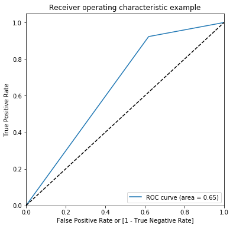

```
(array([0.        , 0.61904762, 1.        ]),
 array([0.        , 0.92307692, 1.        ]),
 array([2, 1, 0], dtype=int64))
```

```python
draw_roc(y_pred_final.Outcome, y_pred_final.predicted)
```

```python
#draw_roc(y_pred_final.Churn, y_pred_final.predicted)
"{:2.2f}".format(metrics.roc_auc_score(y_pred_final.Outcome, y_pred_final.Outcome_Prob))
```

```
'0.65'
```

## PCA on the data

#### While computng the principal components, we must not include the entire dataset. Model building is all about doing well on the data we haven't seen yet!

So we'll calculate the PCs using the train data, and apply them later on the test data

```python
X_train.shape
```

```
(137, 33)
```

```python
#Improting the PCA module
from sklearn.decomposition import PCA
pca = PCA(svd_solver='randomized', random_state=42)
```

```python
#Doing the PCA on the train data
pca.fit(X_train)
```

```
PCA(copy=True, iterated_power='auto', n_components=None, random_state=42,
  svd_solver='randomized', tol=0.0, whiten=False)
```

Let's plot the principal components and try to make sense of them •We'll plot original features on the first 2 principal components as axes

```python
pca.components_
```

```
array([[-1.66805044e-02,  4.50462817e-03,  1.01326020e-03, ...,
        -1.22637080e-05,  1.84015776e-04, -5.29741065e-04],
       [ 8.28084594e-02, -8.68196667e-03, -6.79377088e-03, ...,
         7.34183197e-05, -5.00374789e-04, -2.17725607e-03],
       [ 9.94513509e-01,  1.40549839e-03, -3.28158872e-02, ...,
         9.02667244e-05, -5.75975549e-03, -1.29379188e-02],
       ...,
       [-5.68585603e-07, -5.26652679e-03,  8.64456232e-06, ...,
        -1.69538541e-01, -3.40083823e-05,  1.90075848e-05],
       [-6.96339844e-06,  2.50796597e-03, -6.44333827e-05, ...,
        -3.17798374e-03, -6.37631722e-05,  2.69680745e-06],
       [ 1.94513805e-06, -5.98566854e-04,  5.92282457e-06, ...,
        -7.57308716e-02,  6.46306999e-06, -7.51749230e-07]])
```

```python
colnames = list(X_train.columns)
pcs_df = pd.DataFrame({'PC1':pca.components_[0],'PC2':pca.components_[1], 'Feature':colnames})
pcs_df.head()
```

|  | PC1 | PC2 | Feature |
| --- | --- | --- | --- |
| 0 | -0.016681 | 0.082808 | Time |
| 1 | 0.004505 | -0.008682 | Realvalued Features1 |
| 2 | 0.001013 | -0.006794 | Realvalued Features2 |
| 3 | 0.030464 | -0.057636 | Realvalued Features3 |
| 4 | 0.506797 | -0.855351 | Realvalued Features4 |

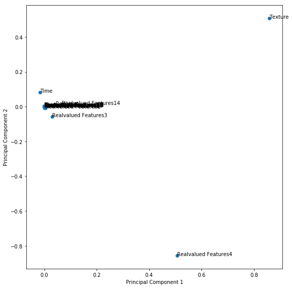

```python
%matplotlib inline
fig = plt.figure(figsize = (8,8))
plt.scatter(pcs_df.PC1, pcs_df.PC2)
plt.xlabel('Principal Component 1')
plt.ylabel('Principal Component 2')
for i, txt in enumerate(pcs_df.Feature):
    plt.annotate(txt, (pcs_df.PC1[i],pcs_df.PC2[i]))
plt.tight_layout()
plt.show()
```

### Looking at the screeplot to assess the number of needed principal components

```python
pca.explained_variance_ratio_
```

```
array([9.61602685e-01, 3.33825941e-02, 2.66380426e-03, 2.03679616e-03,
       1.19117462e-04, 1.01503896e-04, 7.13194445e-05, 7.87443209e-06,
       6.89095526e-06, 5.85780750e-06, 7.33382879e-07, 5.02834147e-07,
       1.75161007e-07, 9.09495732e-08, 2.87250287e-08, 1.19750068e-08,
       5.60594910e-09, 3.11290567e-09, 2.25924558e-09, 7.63150463e-10,
       4.32101220e-10, 3.79089266e-10, 3.35134418e-10, 2.44497506e-10,
       1.43764566e-10, 8.57960171e-11, 3.24624249e-11, 3.04515735e-11,
       2.58459577e-11, 7.11721169e-12, 6.12303205e-12, 2.22885516e-12,
       3.58322643e-13])
```

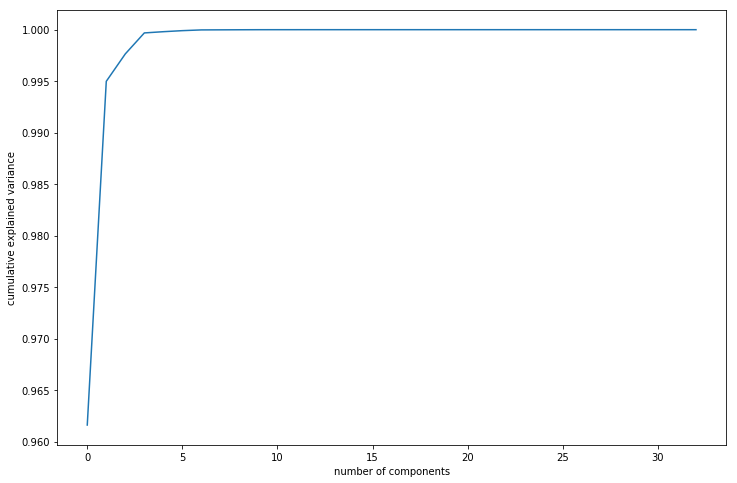

```python
#Making the screeplot - plotting the cumulative variance against the number of components
%matplotlib inline
fig = plt.figure(figsize = (12,8))
plt.plot(np.cumsum(pca.explained_variance_ratio_))
plt.xlabel('number of components')
plt.ylabel('cumulative explained variance')
plt.show()
```

Looks like 6 components are enough to describe 98% of the variance in the dataset •We'll choose 6 components for our modeling

```python
#Using incremental PCA for efficiency - saves a lot of time on larger datasets
from sklearn.decomposition import IncrementalPCA
pca_final = IncrementalPCA(n_components=6)
```

#### Basis transformation - getting the data onto our PCs

```python
df_train_pca = pca_final.fit_transform(X_train)
df_train_pca.shape
```

```
(137, 6)
```

### Creating correlation matrix for the principal components - we expect little to no correlation

```python
#creating correlation matrix for the principal components
corrmat = np.corrcoef(df_train_pca.transpose())
```

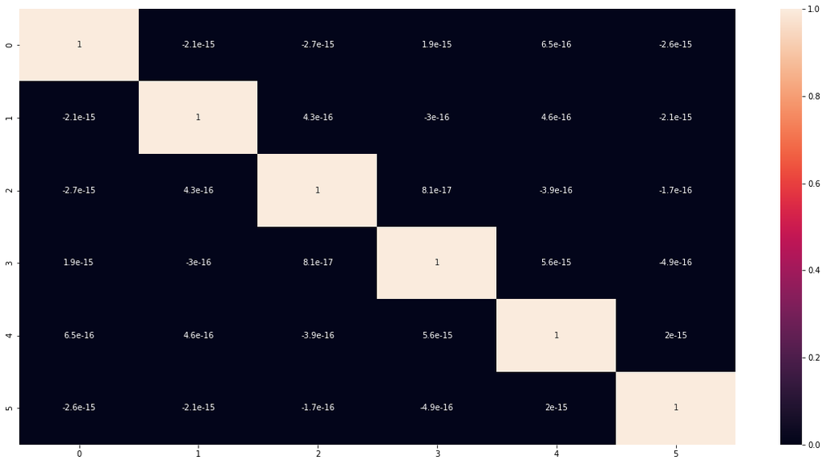

```python
#plotting the correlation matrix
%matplotlib inline
plt.figure(figsize = (20,10))
sns.heatmap(corrmat,annot = True)
```

```python
# 1s -> 0s in diagonals
corrmat_nodiag = corrmat - np.diagflat(corrmat.diagonal())
print("max corr:",corrmat_nodiag.max(), ", min corr: ", corrmat_nodiag.min(),)
# we see that correlations are indeed very close to 0
```

```
max corr: 5.6030764782593604e-15 , min corr:  -2.653011712847609e-15
```

We effectively have removed multicollinearity from our situation, and our models will be much more stable

```python
#Applying selected components to the test data - 16 components
df_test_pca = pca_final.transform(X_test)
df_test_pca.shape
```

```
(60, 6)
```

#### Applying a logistic regression on our Principal Components

• We expect to get similar model performance with significantly lower features • If we can do so, we would have done effective dimensionality reduction without losing any import information

```python
#Training the model on the train data
from sklearn.linear_model import LogisticRegression
from sklearn import metrics

learner_pca = LogisticRegression()
model_pca = learner_pca.fit(df_train_pca,y_train)
```

#### Note

Note that we are fitting the original variable y with the transformed variables (principal components). This is not a problem becuase the transformation done in PCA is linear, which implies that you've only changed the way the new x variables are represented, though the nature of relationship between X and Y is still linear.

```python
#Making prediction on the test data
pred_probs_test = model_pca.predict_proba(df_test_pca)[:,1]
"{:2.2}".format(metrics.roc_auc_score(y_test, pred_probs_test))
```

```
'0.74'
```

#### let PCA select the number of components basen on a variance cutoff we provide

```python
pca_again = PCA(0.90)
```

```python
df_train_pca2 = pca_again.fit_transform(X_train)
df_train_pca2.shape
```

```
(137, 1)
```

```python
#training the regression model
learner_pca2 = LogisticRegression()
model_pca2 = learner_pca2.fit(df_train_pca2,y_train)
```

```python
df_test_pca2 = pca_again.transform(X_test)
df_test_pca2.shape
```

```
(60, 1)
```

```python
#Making prediction on the test data
pred_probs_test2 = model_pca2.predict_proba(df_test_pca2)[:,1]
"{:2.2f}".format(metrics.roc_auc_score(y_test, pred_probs_test2))
```

```
'0.58'
```

#### Let's Visualize

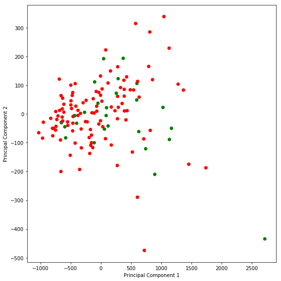

```python
%matplotlib inline
fig = plt.figure(figsize = (8,8))
plt.scatter(df_train_pca[:,0], df_train_pca[:,1], c = y_train.map({0:'green',1:'red'}))
plt.xlabel('Principal Component 1')
plt.ylabel('Principal Component 2')
plt.tight_layout()
plt.show()
```

```python
%matplotlib notebook
from mpl_toolkits.mplot3d import Axes3D
fig = plt.figure(figsize=(8,8))
ax = Axes3D(fig)
# ax = plt.axes(projection='3d')
ax.scatter(df_train_pca[:,2], df_train_pca[:,0], df_train_pca[:,1], c=y_train.map({0:'green',1:'red'}))
```

[output not shown]

#### try building the model with just 3 principal components

```python
pca_last = PCA(n_components=3)
df_train_pca3 = pca_last.fit_transform(X_train)
df_test_pca3 = pca_last.transform(X_test)
df_test_pca3.shape
```

```
(60, 3)
```

```python
#training the regression model
learner_pca3 = LogisticRegression()
model_pca3 = learner_pca3.fit(df_train_pca3,y_train)
#Making prediction on the test data
pred_probs_test3 = model_pca3.predict_proba(df_test_pca3)[:,1]
"{:2.2f}".format(metrics.roc_auc_score(y_test, pred_probs_test3))
```

```
'0.80'
```